# Statistical analysis using Python and R

# Statistical analysis using Python and R

- Python: `Statsmodels`, `scikit-learn`
  - `NumPy`, `SciPy`: overlapping functionality
- R: statistician-designed and focused
- advanced analysis: R has more to offer, more libraries available
- many comparable libraries between the two
  - basic stats: either useful
  - basic & advanced: R gets edge
  - machine learning: either useful (Python more likely)

# (G)LMMs, GLMs, and ANOVA

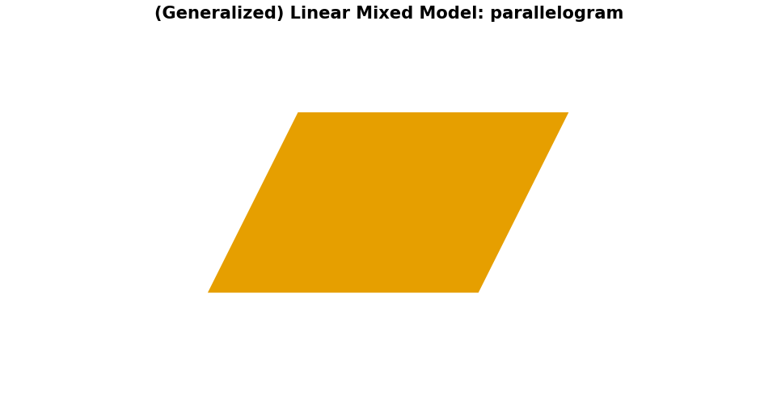

```python
verts = [(0.0, 0.0), (0.50, 2.0), (2.0, 2.0), (1.5, 0), (0.0, 0.0)]

codes = [Path.MOVETO, Path.LINETO, Path.LINETO, Path.LINETO, Path.CLOSEPOLY]

path = Path(verts, codes)

fig = plt.figure(figsize = (16, 8))

ax = fig.add_subplot(111)

patch = patches.PathPatch(path, facecolor = '#E69F00', lw = 0)

ax.add_patch(patch)

ax.set_title('(Generalized) Linear Mixed Model: parallelogram', fontsize = 21, fontweight = 'bold')

ax.axis('off')
ax.set_xlim(-1, 3);
ax.set_ylim(-1, 3);
```

# (Generalized) Linear Mixed Models

- general case
- can be implemented, but can be difficult in the real world
- at times poorly understood/under-specified
- if you can implement in a defensible manner, great

# (Generalized) Linear Mixed Models

- rule of thumb for fixed and random effects
  - fixed: affects mean
  - random: affects variance
  - real world: predictor dies both
- balanced vs. unbalanced (missing observations vs. missing participation)
- `Subject/Participant` is a random effect at the very least
- discuss other experimental paradigms as they come up

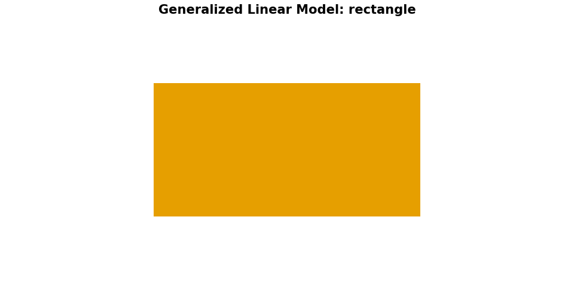

```python
verts = [(0.0, 0.0), (0.0, 2.0), (2.0, 2.0), (2.0, 0), (0.0, 0.0)]

codes = [Path.MOVETO, Path.LINETO, Path.LINETO, Path.LINETO, Path.CLOSEPOLY]

path = Path(verts, codes)

fig = plt.figure(figsize = (16, 8))

ax = fig.add_subplot(111)

patch = patches.PathPatch(path, facecolor = '#E69F00', lw = 0)

ax.add_patch(patch)

ax.set_title('Generalized Linear Model: rectangle', fontsize = 21, fontweight = 'bold')

ax.axis('off')
ax.set_xlim(-1, 3);
ax.set_ylim(-1, 3);
```

# Generalized Linear Models

- special case of the general
- applies to many situations (if conditions are met)
- some difficulties in implementing (e.g., overdispersion)
- useful in many cases

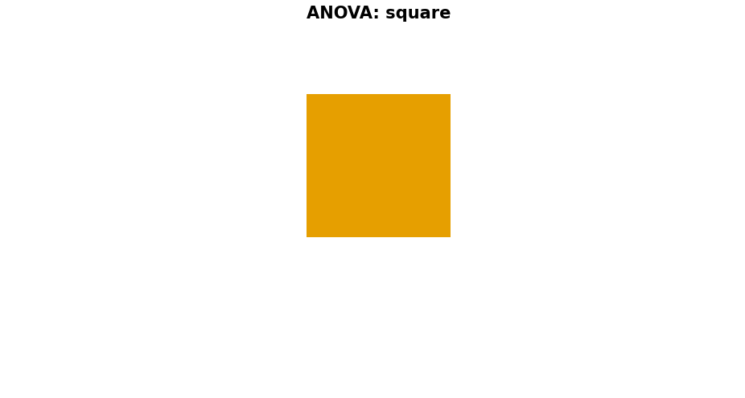

```python
verts = [(0.0, 0.0), (0.0, 2.0), (1.0, 2.0), (1.0, 0.0), (0.0, 0.0)]

codes = [Path.MOVETO, Path.LINETO, Path.LINETO, Path.LINETO, Path.CLOSEPOLY]

path = Path(verts, codes)

fig = plt.figure(figsize = (16, 8))

ax = fig.add_subplot(111)

patch = patches.PathPatch(path, facecolor = '#E69F00', lw = 0)

ax.add_patch(patch)

ax.set_title('ANOVA: square', fontsize = 21, fontweight = 'bold')

ax.axis('off')
ax.set_xlim(-2, 3);
ax.set_ylim(-2, 3);
```

# ANOVA

- special case of the special case
- experimental data often do not meet assumptions
- not really suggested if you can do better

# Classical tests

- what are the questions being asked
- have you examined the data at all, i.e., distributions, summaries, etc.
- use appropriate test for the question/data
- most tests readily available

# Regression

- predictors/factors: continuous (or discrete), categorical or both
- contrasts, significance, output
- interpretation
- plotting: overall, component + residual plots; plotting residuals
- diagnostics: checking significance of predictors, residuals (see also additional via `car` package)

# Formula notation

- what the notation means (structure) - see [`patsy` documentation](https://patsy.readthedocs.org/en/latest/) and [R reference card 2.0](http://cran.r-project.org/doc/contrib/Baggott-refcard-v2.pdf)
- specifying terms
- symbol meanings

# Formula notation

- form: `response ~ predictor1 + predctor2 + ....`
- symbols:
  - `+`: include in model
  - `-`: delete from model
  - `*`: include predictors and calculate interactions
  - `:`: interaction
  - `^`: crossing to *nth* degree
  - `|`: conditional on (goes in parentheses in R usually)

For a clear explanation, [see this PDF](http://faculty.chicagobooth.edu/richard.hahn/teaching/FormulaNotation.pdf)

# R

- stats-oriented [(see video about development)](http://www.r-bloggers.com/why-has-r-despite-quirks-been-so-successful/) and [this post](http://www.r-bloggers.com/why-has-r-despite-quirks-been-so-successful/)
- lots of functionality [(see CRAN task views)](http://cran.r-project.org/web/views/)
- easy to plot/inspect regression outcome/diagnostics
- 'bleeding edge' of statistical modeling

# `scikit-learn`

- machine-learning oriented
- still good for 'simple' analyses
- useful for prediction/classification or more complex problems
- `caret` package in R for machine learning

# `NumPy`, `SciPy`, `scikit-learn`, `pandas` vs. R

- speed
- memory handling
- basic/universal vs. domain-specific
- [see R vs. Python infographic: same functionality, depends on comfort and what you need done, likely use BOTH in parallel](http://blog.datacamp.com/r-or-python-for-data-analysis/)
- practical: data munging (general) in Python; statistics in R (additional munging as needed); machine learning in either

# Next steps

Notebooks, code and files on GitHub repo for the course are intended as tutorials and guides. Read and look over them to learn what to do and when a problem arises, you may always ask. The goal is to apply the methods outlined to your own data (and if you do not have any, to the contributed data). If something comes up that was not covered, we will address it, see if anyone else is having the same issues and a fix will be applied and listed [in the `extras` directory](https://github.com/IRCS-analysis-mini-courses/reproducible-research/tree/master/extras).

1. Look over notebook.
2. Analyze data data using either Python or R (both even)
3. Use IPython notebook as IDE to track changes on project; analyses can be done in Python or R (use of RStudio will be covered on Day 3)
4. Work towards being able to implement explanation and demonstration of each analysis step and reasoning using a combination of Markdown and code cells